# Instrument specificity simulations

```r
library(tidyverse)
library(simulateGP)
library(pbapply)
library(parallel)
library(pROC)
```

Function to estimate the proportion overlap

```r
prop_overlap = function(b_disc, b_rep, se_disc, se_rep, alpha)
{
  p_sign <- pnorm(-abs(b_disc) / se_disc) * pnorm(-abs(b_disc) / se_rep) + ((1 - pnorm(-abs(b_disc) / se_disc)) * (1 - pnorm(-abs(b_disc) / se_rep)))
  p_sig <- pnorm(-abs(b_disc) / se_rep + qnorm(alpha / 2)) + (1 - pnorm(-abs(b_disc) / se_rep - qnorm(alpha / 2)))
  p_rep <- pnorm(abs(b_rep)/se_rep, lower.tail=FALSE)
  res <- dplyr::tibble(
    nsnp=length(b_disc),
    metric=c("Sign", "Sign", "P-value", "P-value"),
    datum=c("Expected", "Observed", "Expected", "Observed"),
    value=c(sum(p_sign, na.rm=TRUE), sum(sign(b_disc) == sign(b_rep)), sum(p_sig, na.rm=TRUE), sum(p_rep < alpha, na.rm=TRUE))
  )
  return(list(res=res, variants=dplyr::tibble(sig=p_sig, sign=p_sign, fdisc=b_disc^2/se_disc^2, frep=b_rep^2/se_rep^2)))
}
```

Simulate GWAS in pop1 and pop2 - independent allele frequencies - some amount of shared causal variants - effect sizes the same if causal variant is shared

```r
sim1 <- function(nsnp1, nsnp2, nshared, nid1, nid2, hsq1, hsq2, S1, S2, sim=1, winnerscurse=TRUE)
{
    # Create map of variants
  nsnp <- nsnp1 + nsnp2 + nshared
  map1 <- tibble(snp=1:nsnp, af=runif(nsnp, 0.05, 0.95), what=c(rep("1", nsnp1), rep("2", nsnp2), rep("both", nshared)))
  map2 <- tibble(snp=1:nsnp, af=runif(nsnp, 0.05, 0.95), what=c(rep("1", nsnp1), rep("2", nsnp2), rep("both", nshared)))

  # Generate summary stats
  x1 <- subset(map1, what != "2") %>%
    generate_gwas_params(., h2=hsq1, Pi=1, S=S1) %>%
    {bind_rows(
      .,
      subset(map1, what == "2") %>% mutate(beta=0)
    )} %>%
    arrange(snp)

  x2 <- subset(map2, what != "1") %>%
    generate_gwas_params(., h2=hsq2, Pi=1, S=S2) %>%
    {bind_rows(
      .,
      subset(map2, what == "1") %>% mutate(beta=0)
    )} %>%
    arrange(snp)
  x2$beta[x2$what=="both"] <- x1$beta[x1$what=="both"]

  b1 <- x1$beta
  b2 <- x2$beta
  x1 <- x1 %>%
    generate_gwas_ss(., nid=nid1)
  x1$beta <- b1

  x2 <- x2 %>%
    generate_gwas_ss(., nid=nid2)
  x2$beta <- b2

  # Check if any significant hits exist
  s1 <- subset(x1, pval < 5e-8)$snp
  if(length(s1) == 0) {
    return(NULL)
  }
  s2 <- subset(x2, pval < 5e-8)$snp
  if(length(s2) == 0) {
    return(NULL)
  }

  # Calculate replication of pop1 hits in pop2
  thresh1 <- 0.05/length(s1)
  if(winnerscurse)
  {
    o1 <- prop_overlap(x1$bhat[s1], x2$bhat[s1], x1$se[s1], x2$se[s1], thresh1)
  } else {
    o1 <- prop_overlap(rnorm(length(s1), x1$beta[s1], x1$se[s1]), x2$bhat[s1], x1$se[s1], x2$se[s1], thresh1)
  }
  o1$variants$snp <- s1
  o1$variants$truth <- x2$what[s1] %in% c("2", "both")
  o1$variants$obs_sig <- x2$pval[s1] < thresh1
  o1$variants$obs_sign <- sign(x2$bhat[s1]) == sign(x1$bhat[s1])
  o1$variants$correct_sig <- o1$variants$truth == o1$variants$obs_sig
  o1$variants$pred <- o1$variants$sig
  o1$variants$pred[!o1$variants$obs_sig] <- 1 - o1$variants$pred[!o1$variants$obs_sig]

  # Calculate replication of pop2 hits in pop1
  thresh2 <- 0.05/length(s2)
  if(winnerscurse)
  {
    o2 <- prop_overlap(x2$bhat[s2], x1$bhat[s2], x2$se[s2], x1$se[s2], thresh2)
  } else {
    o2 <- prop_overlap(rnorm(length(s2), x2$beta[s2], x2$se[s2]), x1$bhat[s2], x2$se[s2], x1$se[s2], thresh2)
  }
  o2$variants$snp <- s2
  o2$variants$truth <- x1$what[s2] %in% c("1", "both")
  o2$variants$obs_sig <- x1$pval[s2] < thresh2
  o2$variants$obs_sign <- sign(x1$bhat[s2]) == sign(x2$bhat[s2])
  o2$variants$correct_sig <- o2$variants$truth == o2$variants$obs_sig
  o2$variants$pred <- o2$variants$sig
  o2$variants$pred[!o2$variants$obs_sig] <- 1 - o2$variants$pred[!o2$variants$obs_sig]

  # truth = whether a variant actually has an effect in both pops
  # pred = prob(sig) (for overlaps) or 1-prob(sig) (for non-overlaps)
  # auc = extent to which pred can predict truth
  o1$auc <- tryCatch(as.numeric(suppressMessages(auc(o1$variants$truth, o1$variants$pred))), error=function(e) return(NA))
  o2$auc <- tryCatch(as.numeric(suppressMessages(auc(o2$variants$truth, o2$variants$pred))), error=function(e) return(NA))

  obs_rep1 = subset(o1$res, metric == "P-value" & datum == "Observed")$value[1]
  obs_rep2 = subset(o2$res, metric == "P-value" & datum == "Observed")$value[1]
  exp_rep1 = subset(o1$res, metric == "P-value" & datum == "Expected")$value[1]
  exp_rep2 = subset(o2$res, metric == "P-value" & datum == "Expected")$value[1]
  binom1 = binom.test(x=obs_rep1, n=length(s1), p=exp_rep1/length(s1))
  binom2 = binom.test(x=obs_rep2, n=length(s2), p=exp_rep2/length(s2))

  res <- tibble(
    nsnp1=nsnp1, nsnp2=nsnp2, nshared=nshared, nid1=nid1, nid2=nid2, hsq1=hsq1, hsq2=hsq2, S1=S1, S2=S2, winnerscurse=winnerscurse, nsig1=length(s1), nsig2=length(s2), auc1=o1$auc, auc2=o2$auc, sim=sim, correct_sig1=sum(o1$variants$correct_sig)/length(o1$variants$correct_sig), correct_sig2=sum(o2$variants$correct_sig)/length(o2$variants$correct_sig), obs_rep1=obs_rep1, obs_rep2=obs_rep2, exp_rep1=exp_rep1, exp_rep2=exp_rep2, binom_p1 = binom1$p.value, binom_p2 = binom2$p.value
  )

  return(res)
}
```

```r
sim1(nsnp1=0, nsnp2=0, nshared=300, nid1=10000, nid2=10000, hsq1=0.4, hsq2=0.4, S1=1, S2=1) %>% as.list()
```

[output not shown]

Perform simulations for a range of sample sizes

```r
param <- expand.grid(
  nsnp1=1000,
  nsnp2=1000,
  nshared=c(1000),
  nid1=100000,
  nid2=seq(1000,100000,by=1000),
  hsq1=0.4,
  hsq2=0.4,
  S1=1,
  S2=1,
  sim=1:10
)

o <- lapply(1:nrow(param), function(i)
  {
    do.call(sim1, args=param[i,])
  }) %>% bind_rows()
```

```r
o %>%
  ggplot(., aes(x=nid2, y=auc2)) +
  geom_point()
```

As discovery sample size increases the replication gets worse - this is because discovery finds more smaller effects which are harder to replicate. Winner’s curse may play a role.

```r
o %>%
  ggplot(., aes(x=nid2, y=auc1)) +
  geom_point()
```

As replication sample size gets smaller the per-variant AUC tends towards random chance

```r
o %>% ggplot(., aes(x=auc1, y=correct_sig1)) +
geom_point()
```

AUC is roughly the same as the fraction of significant variants being correct

```r
o %>% ggplot(., aes(x=auc2, y=correct_sig2)) +
geom_point()
```

AUC is roughly the same as the fraction of significant variants being correct

```r
o %>% ggplot(., aes(y=obs_rep1 / exp_rep1, x=nsig2)) +
  geom_point()
```

- The estimated replication rate matches the expected replication rate
- The per-variant prediction gets worse as the power gets worse

```r
param <- expand.grid(
  nsnp1=0,
  nsnp2=0,
  nshared=c(3000),
  nid1=100000,
  nid2=seq(10000,500000,by=5000),
  hsq1=0.4,
  hsq2=0.4,
  S1=1,
  S2=1,
  winnerscurse=c(TRUE, FALSE),
  sim=1:10
)

o2 <- lapply(1:nrow(param), function(i)
  {
    do.call(sim1, args=param[i,])
  }) %>% bind_rows()
```

```r
o2 %>% ggplot(., aes(y=obs_rep1 / exp_rep1, x=nid2)) +
  geom_point(aes(colour=winnerscurse))
```

```r
o2 %>% ggplot(., aes(y=obs_rep2 / exp_rep2, x=nid2)) +
  geom_point(aes(colour=winnerscurse))
```

```r
o2 %>% ggplot(., aes(y=-log10(binom_p1), x=nid2)) +
  geom_point(aes(colour=winnerscurse)) +
  geom_smooth(aes(colour=winnerscurse))
```

```r
o2 %>% ggplot(., aes(y=-log10(binom_p2), x=nid2)) +
  geom_point(aes(colour=winnerscurse)) +
  geom_smooth(aes(colour=winnerscurse))
```

- The prediction of overall number predicted to replicate matches the actual number of shared variants well but gets noisier when power gets lower
- Testing if the difference in expected and observed seems to work except when replication sample size is small - at which point it becomes important to control for winner’s curse of the discovery effect estimate

```r
param <- expand.grid(
  nsnp1=seq(0, 3000, by=750),
  nsnp2=seq(0, 3000, by=750),
  nshared=c(3000),
  nid1=100000,
  nid2=seq(50000,500000,by=100000),
  hsq1=0.4,
  hsq2=0.4,
  S1=1,
  S2=1,
  winnerscurse=c(TRUE, FALSE),
  sim=1:8
)

o3 <- lapply(1:nrow(param), function(i)
  {
    do.call(sim1, args=param[i,])
  }) %>% bind_rows()
```

```r
o3 %>% group_by(pshared=nshared/(nshared+nsnp1+nsnp2), nid2, winnerscurse) %>%
  summarise(pow=sum(binom_p2 < 0.05)/n()) %>%
  ggplot(., aes(y=pow, x=pshared)) +
    geom_point(aes(colour=as.factor(log(nid2)))) +
    geom_line(aes(colour=as.factor(log(nid2)), group=nid2)) +
    facet_grid(. ~ winnerscurse)
```

```r
o3 %>% group_by(pshared=nshared/(nshared+nsnp1+nsnp2), nid2, winnerscurse) %>%
  summarise(pow=sum(binom_p1 < 0.05)/n()) %>%
  ggplot(., aes(y=pow, x=pshared)) +
    geom_point(aes(colour=as.factor(log(nid2)))) +
    geom_line(aes(colour=as.factor(log(nid2)), group=nid2)) +
    facet_grid(. ~ winnerscurse)
```

```r
o3 %>% ggplot(., aes(y=-log10(binom_p2), x=nshared/(nshared+nsnp1+nsnp2))) +
  geom_point(aes(colour=winnerscurse))
```

```r
cont <-
o3 %>% group_by(pshared=nshared/(nshared+nsnp1+nsnp2), nid2, winnerscurse) %>%
  summarise(pow=sum(binom_p2 < 0.05)/n()) %>%
  ggplot(., aes(y=pow, x=pshared)) +
    geom_point(aes(colour=nid2)) +
    geom_smooth(aes(colour=nid2)) +
    facet_grid(. ~ winnerscurse)
```

## LD regions

Now run simulations that allow for the raw and maxz methods for testing for replication

### Generate LD matrices for simulations

```r
bEUR <- "/Users/gh13047/repo/mr-base-api/app/ld_files/EUR"
bAFR <- "/Users/gh13047/repo/mr-base-api/app/ld_files/AFR"
bEAS <- "/Users/gh13047/repo/mr-base-api/app/ld_files/EAS"

varrefEUR <- simulateGP:::variant_reference(bEUR)
varrefAFR <- simulateGP:::variant_reference(bAFR)
varrefEAS <- simulateGP:::variant_reference(bEAS)
```

```r
regions <- system.file(paste0("extdata/ldetect/EUR.bed"), package = "simulateGP") %>%
        data.table::fread(., header = TRUE) %>% dplyr::mutate(chr = as.numeric(gsub("chr",
        "", chr)), start = as.numeric(start), stop = as.numeric(stop)) %>%
        dplyr::as_tibble()
```

```r
mapEUR <- generate_ldobj("ldEUR", bEUR, regions[c(100), ])
mapEAS <- generate_ldobj("ldEAS", bEAS, regions[c(100), ])
mapAFR <- generate_ldobj("ldAFR", bAFR, regions[c(100), ])
```

```r
ldEUR <- read_ldobjdir("ldEUR")[[1]]
ldAFR <- read_ldobjdir("ldAFR")[[1]]
ldEAS <- read_ldobjdir("ldEAS")[[1]]
```

```r
organise_ldobj <- function(dir1, dir2, region)
{
  ld1 <- readRDS(file.path(dir1, paste0("ldobj_", region, ".rds")))
  ld2 <- readRDS(file.path(dir2, paste0("ldobj_", region, ".rds")))
  x1 <- unique(ld1$map$snp)
  x1 <- x1[x1 %in% ld1$map$snp]
  x1 <- x1[x1 %in% ld2$map$snp]
  i1 <- which(ld1$map$snp %in% x1)
  ld1$map <- ld1$map[i1,]
  ld1$ld <- ld1$ld[i1, i1]
  i2 <- which(ld2$map$snp %in% x1)
  ld2$map <- ld2$map[i2,]
  ld2$ld <- ld2$ld[i2, i2]
  stopifnot(all(ld1$map$snp == ld2$map$snp))
  return(list(ld1=ld1, ld2=ld2))
}
```

### Function for developing simulated GWAS summary data from LD matrices

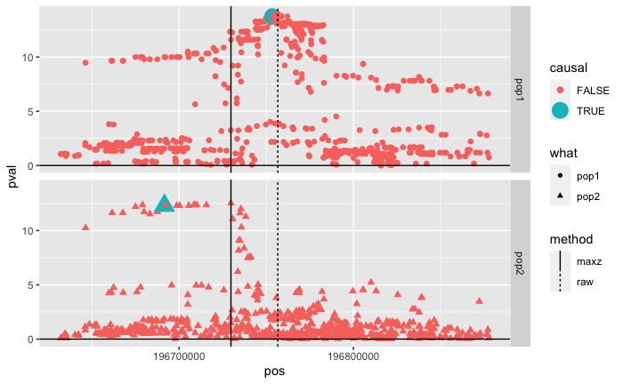

```r
subset_ldobj <- function(ldobj, snps)
{
  i <- which(ldobj$map$snp %in% snps)
  ldobj$map <- ldobj$map[i,]
  ldobj$ld <- ldobj$ld[i,i]
  return(ldobj)
}

simss <- function(ld1, ld2, nid1, nid2, type, hsq1, window)
{
  x1 <- ld1$map %>%
    generate_gwas_params(h2=hsq1, S=0, Pi=1/nrow(.))
  pos1 <- x1$pos[x1$beta != 0] - window/2
  pos2 <- pos1 + window

  x1 <- subset(x1, pos >= pos1 & pos <= pos2)
  ld1 <- subset_ldobj(ld1, x1$snp)
  ld2 <- subset_ldobj(ld2, x1$snp)

  x1 <- x1 %>%
    generate_gwas_ss(nid=nid1, ldobj=ld1)

  x2 <- ld2$map %>% generate_gwas_params(h2=hsq1, S=0, Pi=1/nrow(.))
  if(type=="shared")
  {
    x2$beta <- x1$beta
  } else if(type == "1") {
    x2$beta <- 0
  }

  x2 <- x2 %>%
    generate_gwas_ss(nid=nid2, ldobj=ld2)

  return(list(x1=x1, x2=x2))
}

plot_simss <- function(s)
{
  raw <- which.max(s[[1]]$fval)
  maxz <- which.max(s[[1]]$fval + s[[2]]$fval)
  i <- tibble(pos=c(s[[1]]$pos[raw], s[[1]]$pos[maxz]), method=c("raw", "maxz"))
  rbind(
    tibble(snp=s[[1]]$snp, pos=s[[1]]$pos, pval=-log10(s[[1]]$pval), causal=s[[1]]$beta != 0, what="pop1"),
    tibble(snp=s[[1]]$snp, pos=s[[1]]$pos, pval=-log10(s[[2]]$pval), causal=s[[2]]$beta != 0, what="pop2")
  ) %>%
    ggplot(., aes(x=pos, y=pval)) +
    geom_point(aes(colour=causal, size=causal, shape=what)) +
    facet_grid(what ~ .) +
    geom_hline(yintercept=0) +
    geom_vline(data=i, aes(xintercept=pos, linetype=method))
}
ld <- organise_ldobj("ldEUR", "ldAFR", "1_196176201_197311514")
ld1 <- ld[[1]]
ld2 <- ld[[2]]
s <- simss(ld1, ld2, 10000, 10000, "distinct", 0.008, 250000)
plot_simss(s)
```

```r
sim2 <- function(lddir1, lddir2, region, nid1, nid2, nsim=100, pshared, pdistinct, p1, hsq1=0.004, window=250000, winnerscurse=TRUE, sim=1, mc.cores=1)
{
  type <- sample(c("shared", "distinct", "1"), nsim, replace=T, prob=c(pshared, pdistinct, p1))
  ld <- organise_ldobj(lddir1, lddir2, region)
  l <- mclapply(1:nsim, function(i)
  {
    message(i)
    x <- simss(ld[[1]], ld[[2]], nid1, nid2, type[i], hsq1, window)
    x1 <- x$x1
    x2 <- x$x2
    # Get the top hit for 1 and check for overlap in 2
    x1raw <- subset(x1, fval==max(fval, na.rm=T))[1,]
    x2raw <- subset(x2, snp == x1raw$snp)
    if(winnerscurse)
    {
      oraw <- prop_overlap(x1raw$bhat, x2raw$bhat, x1raw$se, x2raw$se, 0.05/nsim)
    } else {
      oraw <- prop_overlap(rnorm(nrow(x1raw), x1raw$beta, x1raw$se), x2raw$bhat, x1raw$se, x2raw$se, 0.05/nsim)
    }

    fvalsum <- x1$fval + x2$fval
    maxz <- which.max(fvalsum)[1]
    x1maxz <- x1[maxz, ]
    x2maxz <- x2[maxz, ]
    if(winnerscurse)
    {
      omaxz <- prop_overlap(x1maxz$bhat, x2maxz$bhat, x2maxz$se, x2maxz$se, 0.05/nsim)
    } else {
      omaxz <- prop_overlap(rnorm(nrow(x1maxz), x1maxz$beta, x1maxz$se), x2maxz$bhat, x2maxz$se, x2maxz$se, 0.05/nsim)
    }
    return(list(raw=oraw, maxz=omaxz))
  }, mc.cores=mc.cores)

  sig <- which(sapply(l, function(x) !is.null(x)))
  l[sapply(l, is.null)] <- NULL
  o1 <- list(res=l[[1]]$raw$res)
  o1$variants <- lapply(l, function(x)
  {
    x$raw$variants
  }) %>% bind_rows()
  o1$res$value <- sapply(l, function(x) x$raw$res$value) %>% rowSums()

  o1$variants$snp <- sig
  o1$variants$truth <- type[sig] == "shared"
  o1$variants$obs_sig <- sapply(l, function(x) x$raw$res$value[4])
  o1$variants$obs_sign <- sapply(l, function(x) x$raw$res$value[2])
  o1$variants$correct_sig <- o1$variants$truth == o1$variants$obs_sig
  o1$variants$pred <- o1$variants$sig
  o1$variants$pred[!o1$variants$obs_sig] <- 1 - o1$variants$pred[!o1$variants$obs_sig]


  o2 <- list(res=l[[1]]$maxz$res)
  o2$variants <- lapply(l, function(x)
  {
    x$maxz$variants
  }) %>% bind_rows()
  o2$res$value <- sapply(l, function(x) x$maxz$res$value) %>% rowSums()

  o2$variants$snp <- sig
  o2$variants$truth <- type[sig] == "shared"
  o2$variants$obs_sig <- sapply(l, function(x) x$maxz$res$value[4])
  o2$variants$obs_sign <- sapply(l, function(x) x$maxz$res$value[2])
  o2$variants$correct_sig <- o2$variants$truth == o2$variants$obs_sig
  o2$variants$pred <- o2$variants$sig
  o2$variants$pred[!o2$variants$obs_sig] <- 1 - o2$variants$pred[!o2$variants$obs_sig]

  # truth = whether a variant actually has an effect in both pops
  # pred = prob(sig) (for overlaps) or 1-prob(sig) (for non-overlaps)
  # auc = extent to which pred can predict truth
  o1$auc <- tryCatch(as.numeric(suppressMessages(auc(o1$variants$truth, o1$variants$pred))), error=function(e) return(NA))
  o2$auc <- tryCatch(as.numeric(suppressMessages(auc(o2$variants$truth, o2$variants$pred))), error=function(e) return(NA))

  perf1 <- o1$variants %>% group_by(truth) %>% summarise(pow=sum(frep > qf(0.05/nsim, 1, nid2, low=F))/n(), meanf=mean(frep))
  perf2 <- o2$variants %>% group_by(truth) %>% summarise(pow=sum(frep > qf(0.05/nsim, 1, nid2, low=F))/n(), meanf=mean(frep))
  print(perf1)
  print(perf2)
  print(o1$variants)
  print(o2$variants)

  obs_rep1 = subset(o1$res, metric == "P-value" & datum == "Observed")$value[1]
  obs_rep2 = subset(o2$res, metric == "P-value" & datum == "Observed")$value[1]
  exp_rep1 = subset(o1$res, metric == "P-value" & datum == "Expected")$value[1]
  exp_rep2 = subset(o2$res, metric == "P-value" & datum == "Expected")$value[1]
  binom1 = binom.test(x=obs_rep1, n=length(sig), p=exp_rep1/length(sig))
  binom2 = binom.test(x=obs_rep2, n=length(sig), p=exp_rep2/length(sig))

  res <- tibble(
    lddir1=lddir1, lddir2=lddir2, region=region, nid1=nid1, nid2=nid2, pshared=pshared, pdistinct=pdistinct, p1=p1, hsq1=hsq1, window=window, winnerscurse=winnerscurse, nsig=length(sig), auc1=o1$auc, auc2=o2$auc, sim=sim, correct_sig1=sum(o1$variants$correct_sig)/length(o1$variants$correct_sig), correct_sig2=sum(o2$variants$correct_sig)/length(o2$variants$correct_sig), obs_rep1=obs_rep1, obs_rep2=obs_rep2, exp_rep1=exp_rep1, exp_rep2=exp_rep2, binom_p1 = binom1$p.value, binom_p2 = binom2$p.value, fdr1=subset(perf1, !truth)$pow, fdr2=subset(perf2, !truth)$pow, pow1=subset(perf1, truth)$pow, pow2=subset(perf2, truth)$pow
  )

  return(res)

}
```

```r
o <- sim2("ldEUR", "ldEAS", "1_196176201_197311514", 10000, 10000, 1/2, 0, 1/2, nsim=10, hsq1=0.004, window=250000, winnerscurse=TRUE)
```

```
1
2
3
4
5
6
7
8
9
10
```

| truth | pow | meanf |
| --- | --- | --- |
| FALSE | 0 | 0.9902868 |
| TRUE | 1 | 30.3148480 |

| truth | pow | meanf |
| --- | --- | --- |
| FALSE | 0 | 0.9902868 |
| TRUE | 1 | 33.3806506 |

| sig | sign | fdisc | frep | snp | truth | obs_sig | obs_sign | correct_sig | pred |
| --- | --- | --- | --- | --- | --- | --- | --- | --- | --- |
| 0.9871041 | 0.9999998 | 33.71894 | 23.1202890 | 1 | TRUE | 1 | 1 | TRUE | 9.871041e-01 |
| 0.5566374 | 0.9984085 | 43.69693 | 0.3994708 | 2 | FALSE | 0 | 0 | TRUE | 4.433626e-01 |
| 0.9999908 | 1.0000000 | 43.61491 | 38.1828439 | 3 | TRUE | 1 | 1 | TRUE | 9.999908e-01 |
| 0.9999985 | 1.0000000 | 49.93679 | 22.8638320 | 4 | TRUE | 1 | 1 | TRUE | 9.999985e-01 |
| 0.9925215 | 0.9999999 | 48.86837 | 29.7676613 | 5 | TRUE | 1 | 1 | TRUE | 9.925215e-01 |
| 0.9961613 | 0.9999953 | 19.63539 | 57.1639413 | 6 | TRUE | 1 | 1 | TRUE | 9.961613e-01 |
| 0.5990582 | 0.9988857 | 29.63719 | 0.3148305 | 7 | FALSE | 0 | 1 | TRUE | 4.009418e-01 |
| 0.9871469 | 0.9999998 | 53.41485 | 10.7905207 | 8 | TRUE | 1 | 1 | TRUE | 9.871469e-01 |
| 0.9999963 | 1.0000000 | 50.18074 | 2.7103541 | 9 | FALSE | 0 | 0 | TRUE | 3.677356e-06 |
| 0.9998879 | 1.0000000 | 35.49371 | 0.5364919 | 10 | FALSE | 0 | 0 | TRUE | 1.121271e-04 |

| sig | sign | fdisc | frep | snp | truth | obs_sig | obs_sign | correct_sig | pred |
| --- | --- | --- | --- | --- | --- | --- | --- | --- | --- |
| 0.9871041 | 0.9999995 | 25.364975 | 23.1202890 | 1 | TRUE | 1 | 1 | TRUE | 9.871041e-01 |
| 0.5566374 | 0.9968220 | 8.699449 | 0.3994708 | 2 | FALSE | 0 | 0 | TRUE | 4.433626e-01 |
| 0.9999908 | 1.0000000 | 50.282733 | 38.1828439 | 3 | TRUE | 1 | 1 | TRUE | 9.999908e-01 |
| 0.9999985 | 1.0000000 | 55.880681 | 22.8638320 | 4 | TRUE | 1 | 1 | TRUE | 9.999985e-01 |
| 0.9925215 | 0.9999998 | 27.462361 | 29.7676613 | 5 | TRUE | 1 | 1 | TRUE | 9.925215e-01 |
| 0.9938490 | 0.9999999 | 28.200262 | 65.5232709 | 6 | TRUE | 1 | 1 | TRUE | 9.938490e-01 |
| 0.5990582 | 0.9977739 | 9.351022 | 0.3148305 | 7 | FALSE | 0 | 1 | TRUE | 4.009418e-01 |
| 0.9509880 | 0.9999919 | 19.905367 | 20.8260067 | 8 | TRUE | 1 | 1 | TRUE | 9.509880e-01 |
| 0.9999963 | 1.0000000 | 53.146867 | 2.7103541 | 9 | FALSE | 0 | 0 | TRUE | 3.677356e-06 |
| 0.9998879 | 1.0000000 | 42.211446 | 0.5364919 | 10 | FALSE | 0 | 0 | TRUE | 1.121271e-04 |

```r
str(o)
```

```
tibble[,27] [1 × 27] (S3: tbl_df/tbl/data.frame)
 $ lddir1      : chr "ldEUR"
 $ lddir2      : chr "ldEAS"
 $ region      : chr "1_196176201_197311514"
 $ nid1        : num 10000
 $ nid2        : num 10000
 $ pshared     : num 0.5
 $ pdistinct   : num 0
 $ p1          : num 0.5
 $ hsq1        : num 0.004
 $ window      : num 250000
 $ winnerscurse: logi TRUE
 $ nsig        : int 10
 $ auc1        : num 1
 $ auc2        : num 1
 $ sim         : num 1
 $ correct_sig1: num 1
 $ correct_sig2: num 1
 $ obs_rep1    : num 6
 $ obs_rep2    : num 6
 $ exp_rep1    : num 9.12
 $ exp_rep2    : num 9.08
 $ binom_p1    : num 0.00821
 $ binom_p2    : num 0.00955
 $ fdr1        : num 0
 $ fdr2        : num 0
 $ pow1        : num 1
 $ pow2        : num 1
```

```r
param <- expand.grid(
  lddir1="ldEUR",
  lddir2="ldEAS",
  region="1_196176201_197311514",
  nid1=100000,
  nid2=c(50000, 100000, 200000),
  pshared=1/2,
  pdistinct=1/2,
  p1=1/2,
  nsim=100,
  hsq1=0.4,
  window=250000,
  sim=1:5
)

o4 <- lapply(1:nrow(param), function(i)
  {
    do.call(sim2, args=param[i,])
  }) %>% bind_rows()
```

```
1
2
3
4
5
6
```